# Assignment 3 Task 3

Jonah Seif

11/3/2020

## Read in sea urchins data and clean names

```r
urchins_clean <- read_csv(here("data", "urchins.csv")) %>%
  clean_names()
```

## Exploratory data visualization comparing the distribution of sizes between purple and red urchins

- Faceted histogram
- Boxplot with common name on the x-axis and size on y-axis

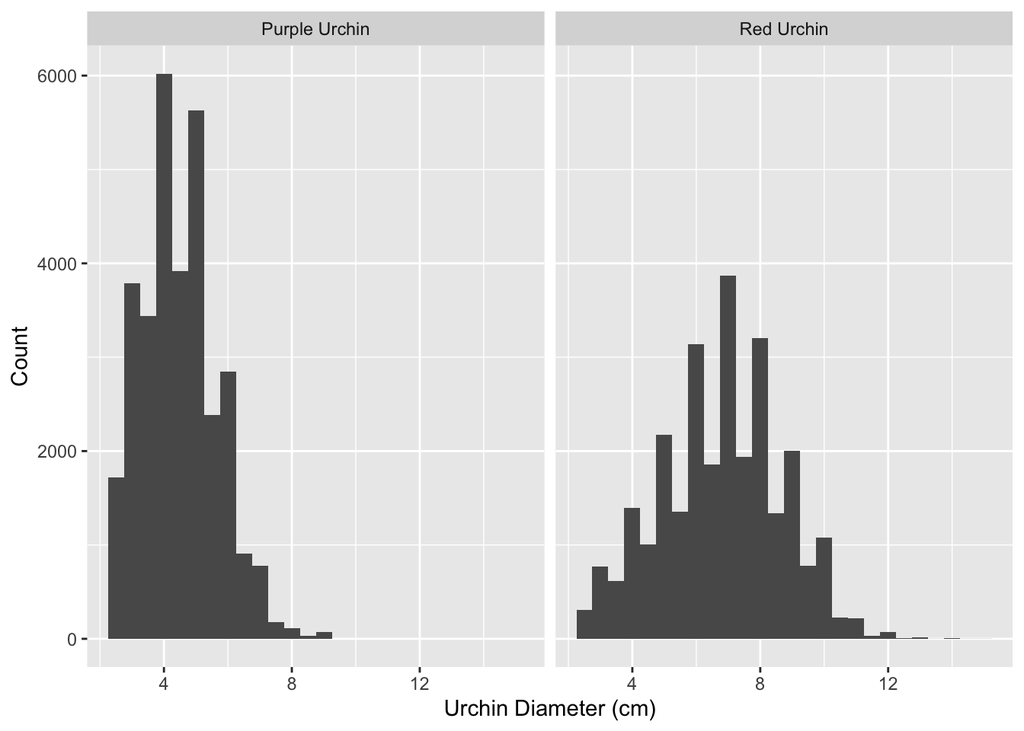

```r
ggplot(data = urchins_clean, aes(x = size)) +
  geom_histogram(binwidth = .5)+
  facet_wrap(~common_name)+
  labs(x = "Urchin Diameter (cm)", y = "Count")
```

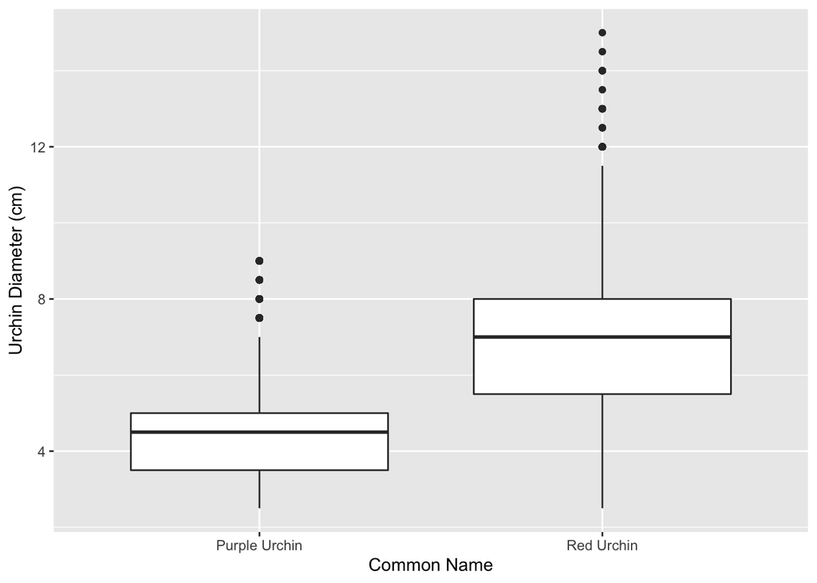

```r
ggplot(data = urchins_clean,
       aes(x = common_name, y = size))+
  geom_boxplot()+
  labs(x = "Common Name", y = "Urchin Diameter (cm)")
```

## Create a summary table of statistics for red and purple urchins

- Contains: mean, median, standard deviation, sample size

```r
urchin_stats <- urchins_clean %>%
  group_by(common_name) %>%
  summarize(mean = mean(size),
            sd = sd(size),
            median = median(size),
            n = n())

urchin_stats
```

```
## # A tibble: 2 x 5
##   common_name    mean    sd median     n
##   <chr>         <dbl> <dbl>  <dbl> <int>
## 1 Purple Urchin  4.47  1.18    4.5 31805
## 2 Red Urchin     6.78  1.89    7   27408
```

```r
urchins_purp <- urchins_clean %>%
  filter(common_name == "Purple Urchin") %>%
  pull(size)

urchins_red <- urchins_clean %>%
  filter(common_name == "Red Urchin") %>%
  pull(size)

cohen.d(urchins_purp, urchins_red)
```

```
##
## Cohen's d
##
## d estimate: -1.489684 (large)
## 95 percent confidence interval:
##     lower     upper
## -1.507930 -1.471437
```

Based on the table and graphs above, we see that purple urchins have a narrower size distribution and a lower mean size compared to red urchins. The histograms show a fairly normal distribution for red urchins and a narrower, close to normal distribution for purple urchins, but with a positive tail. The standard deviation numbers from our table also demonstrate that the red urchin sample population has a greater spread of sizes compared to the purple urchin sample population. Specifically, the absolute difference of the means is 2.31cm (41.1% difference) and the Cohen’s d is 1.49, which would indicate a noticeable difference between mean urchin diameters.

## Explore purple urchin counts by site and year

- Filter to only include observations for purple urchins
- Convert the date to class “Date”
- Create a new column that only contains the year
- Create a new column that contains the full name for each of the five sites

```r
purple_urchins <- urchins_clean %>%
  filter(common_name == "Purple Urchin") %>%
  mutate(date = mdy(date)) %>%
  mutate(year = year(date)) %>%
  mutate(site_full = case_when(
    site == "NAPL" ~ "Naples Reef",
    site == "AQUE" ~ "Arroyo Quemado Reef",
    site == "CARP" ~ "Carpinteria Reef",
    site == "MOHK" ~ "Mohawk Reef",
    site == "IVEE" ~ "Isla Vista Reed"))
```

## Make a summary table for total number of purple urchins observed by site and year

```r
purple_count <- purple_urchins %>%
  group_by(year, site_full) %>%
  count()

purple_count
```

```
## # A tibble: 61 x 3
## # Groups:   year, site_full [61]
##     year site_full               n
##    <dbl> <chr>               <int>
##  1  2008 Arroyo Quemado Reef    67
##  2  2008 Carpinteria Reef      265
##  3  2008 Mohawk Reef           294
##  4  2008 Naples Reef           246
##  5  2009 Arroyo Quemado Reef   926
##  6  2009 Carpinteria Reef     1315
##  7  2009 Mohawk Reef          1344
##  8  2009 Naples Reef          1064
##  9  2010 Arroyo Quemado Reef   921
## 10  2010 Carpinteria Reef      930
## # … with 51 more rows
```

## Make an exploratory graph of purple urchin numbers by site and year

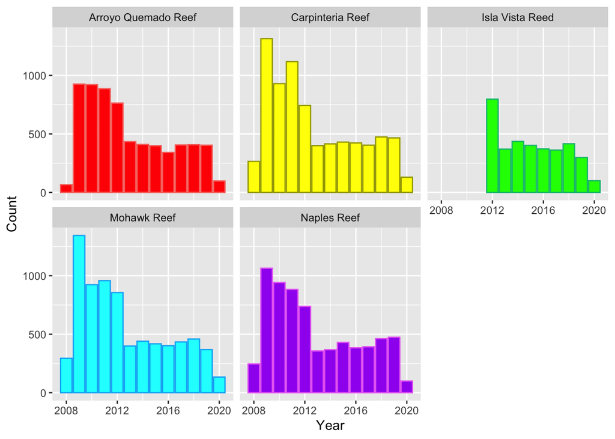

```r
purple_count %>% ggplot(aes(x = year, y = n, fill = site_full))+
  geom_col(aes(color = site_full))+
  scale_fill_manual(values = c("red", "yellow", "green", "cyan", "purple"))+
  facet_wrap(~site_full)+
  theme(legend.position = "none")+
  labs(x = "Year", y = "Count")
```